# Manual

Alec Buchanan & Jason Lawrence

October 11, 2018

## 1. Setup

## 1.1 Windows 10

Windows 10 was the operating system used to build and test the peer and index server.

### 1.2 Python 3.7

The peer and index server were both built and tested using python 3.7 on Windows 10.

#### 1.2.1 Downloading

Python 3.7 can be downloaded from their website at: https://www.python.org/downloads/

#### 1.2.2 Configuration and Installation

1. Run the python 3.7 installer and follow the on screen instructions
2. record the directory that the python.exe was saved in
3. Add the python directory to the global PATH variable

**Note: How to add to PATH variable**

1. open file explorer
2. right click *This PC*
3. *properties*
4. *Advanced system settings*
5. *Environment Variables*
6. *System variables*
7. click *path*
8. click edit
9. add python.exe directory to PATH

[figure not shown]

### 1.3 Peer

#### 1.3.1 Installation

1. Download peer
2. unzip peer if compressed

#### 1.3.2 Configuration

The configuration file is *peerN.conf* located in *\PA2\LeafNode\conf*. The order of which variables go on which lines is important:  
**1**. PEER_SERVER_PORT = Port for the peer server to listen on  
**2**. P2P_PORT = The port that the peer server registers the peer on  
**3**. INDEX_SERVER_IP = IP address of the index server  
**4**. INDEX_SERVER_PORT = Port of the index server  
**5**. LOCAL_SHARED_FILE_SPACE = Directory of shared file space

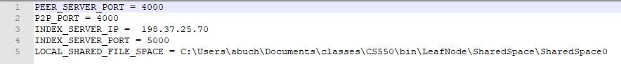

### 1.4 Index Server

#### 1.4.1 Installation

1. Download index server
2. unzip index server if compressed

#### 1.4.2 Configuration

**1** LOCAL_PORT = The port to listen for linear topology queries on  
**2** NEIGHBOR_IP = The neighbor ip address for linear topologies  
**3** NEIGHBOR_PORT = The neighbor super peer port for linear topology  
**4** SUPER_PEER_PORT_BROADCAST = Super peer  
**5** SUPER_PEER_ID = Super peer id  
**6** LEAF_NODE_PORT = Port to listen for leaf nodes on

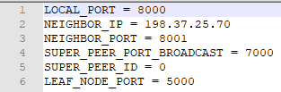

## 2. Execution

### 2.1 Peer

1. make sure peer is properly configured
2. `python <bin directory>\main.py ..\conf\peer0.conf`
3. Enter data as prompted

**Special Commands**:  
*search*: retreives list of registered files on the local index server  
*exit*: exits the program  
*linear*: changes the topology to be linear  
*broadcast*: changes the topology to be broadcast  
*topology*: returns the current topology

*Notice: The super peer needs to know what topology to use. Using the commands above tells the super peer what topology to use.*

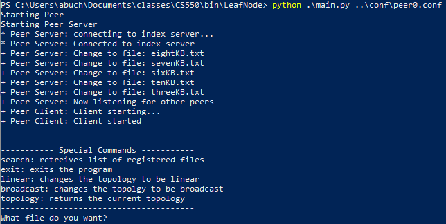

### 2.2 Super Peer

`python <super-peer-bin>\main.py ..\conf\superPeer0.conf`  
The server will start and wait for connections. Any configuration will be done through the conf file.

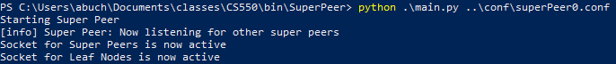

## 3. Test Case

### 3.1 Test 1

This test is used to show that files can be found using linear topology and broadcast topology.

**Steps**

1. Verify the topology is set to Broadcast
2. Peer request file that is registered under a different super peer and print a message acknowledging the download and all queryhits
3. Switch topologies to linear topology
4. Peer request file that is registered under a different super peer and print a message acknowledging the download and all query hits

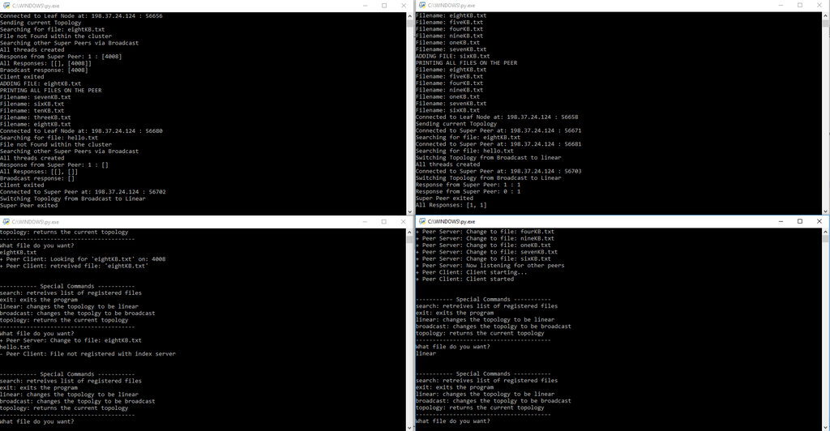

### 3.2 More Tests

Check test.pdf for more information on testing